# Quiz 2 - Econometria 2

Adrian Felipe Ruiz

02/03/2022

```r
ID <- 201820005003
```

## Quiz 1

Antes de empezar:

- En la línea del código de R donde dice ID deben poner su identificador personal, que corresponde a su código de estudiante. Los resultados del código dependen de este indicador, por lo que las respuestas correctas serán diferentes para cada estudiante.

Para este quiz vamos a usar los datos de precios de las acciones de S&P 500 que uso en su primer quiz.

1. (*10 puntos*) Grafique el autocorrelograma de la serie. ¿Que modelo considera usted que es coherente con los resultados encontrados en el autocorrelograma? ¿Por qué?

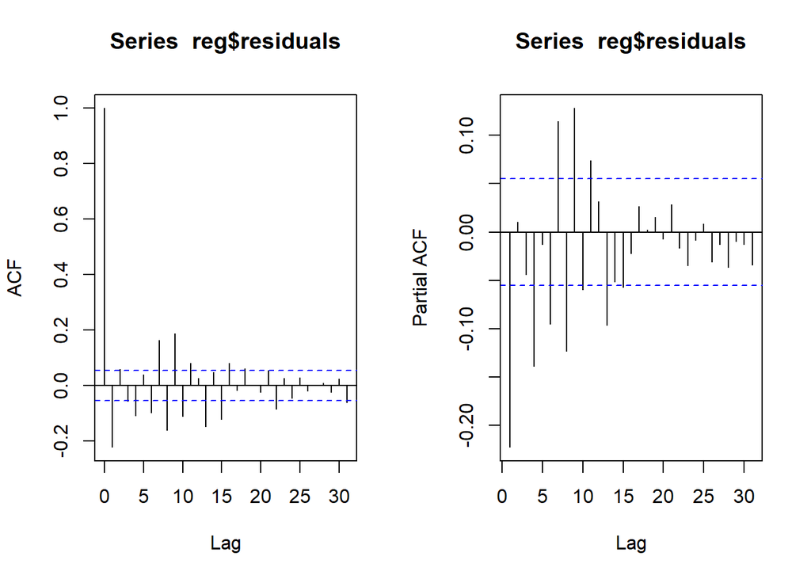

```r
reg<- lm(sp1~ ret)

par(mfrow = c(1,2))
acf(reg$residuals)
pacf(reg$residuals)
```

Interpretación: en el modelo AR se puede decir que se toma un AR9 ya que se puede observar en el autocorrelograma de la parte derecha que hay nueve residuales estadisticamente significativos. El ultimo residual cae aproximandamente en el rezago 16, lo cual nos quiere decir que nos interesa lo que pase 16 periodos hacia atrás.

Por lo tanto podriamos estimar un ARIMA (9,0,11)

El número tan alto de residuales autocorrelacionas se puedar porque estamos trabajando con datos diarios y quizás esten correlacionado lo que pasó el periodo pasado con el periodo siguiente.

2. (*7 puntos*) Estime una regresión del modelo escogido. Interprete el coeficiente estimado.

```r
library(forecast)
```

```r
library(ggplot2)
library(lmtest)
Model<- Arima(ret,
      order = c(9,0,11))
coeftest(Model)
```

```
##
## z test of coefficients:
##
##             Estimate Std. Error z value  Pr(>|z|)
## ar1        0.6497840  0.1781283  3.6478 0.0002645 ***
## ar2       -0.9317193  0.1953365 -4.7698 1.844e-06 ***
## ar3        0.5179827  0.2333872  2.2194 0.0264586 *
## ar4       -0.5523023  0.1799720 -3.0688 0.0021490 **
## ar5        0.4932606  0.2081166  2.3701 0.0177825 *
## ar6       -0.7546208  0.2084450 -3.6202 0.0002943 ***
## ar7        0.3289266  0.2261361  1.4546 0.1457935
## ar8       -0.3681439  0.1465488 -2.5121 0.0120018 *
## ar9       -0.0893913  0.1490248 -0.5998 0.5486118
## ma1       -0.5312460  0.1758983 -3.0202 0.0025262 **
## ma2        0.9882648  0.1769161  5.5861 2.323e-08 ***
## ma3       -0.4774246  0.2317687 -2.0599 0.0394064 *
## ma4        0.5956624  0.1742326  3.4188 0.0006290 ***
## ma5       -0.5356296  0.2099607 -2.5511 0.0107385 *
## ma6        0.7150731  0.2181282  3.2782 0.0010446 **
## ma7       -0.2577209  0.2354569 -1.0946 0.2737111
## ma8        0.3439151  0.1542570  2.2295 0.0257810 *
## ma9        0.2123314  0.1549433  1.3704 0.1705679
## ma10       0.0091774  0.0441857  0.2077 0.8354630
## ma11       0.1922106  0.0373881  5.1410 2.734e-07 ***
## intercept  0.1499504  0.1513480  0.9908 0.3217999
## ---
## Signif. codes:  0 '***' 0.001 '**' 0.01 '*' 0.05 '.' 0.1 ' ' 1
```

Interpretación : se puede ver en el modelo ARIMA que con una significancia del 5% desde AR1 hasta AR6 son estadisticamente significativos y otro que podemos decir que es estadisticamente significativo es el AR8.

Pero con un 1% de significancia podemos decir que os más significativos son el AR6,AR2 y AR1

También podemos ver que desde MA1 hasta MA6 son estadisticamente significativos al 5% y también los son em MA8 y MA11.

Los terminos mencionados anteriormente por ser tan significativos deberián permanecer en el modelo, ya que esto vuelve al modelo más significante. Esto podría decirse que es una condición necesaria pero no suficiente.

Hay terminos que no son significativos como el AR7 y el AR9, al 5% de significancia.

Los coeficientes mensionados anteriormente, al no ser significantivos le quitan significancia al modelo.

3. (*10 puntos*) Grafique el autocorrelograma de los residuales del modelo anterior. ¿Considera usted que el modelo escogido es correcto basado en este autocorrelograma? ¿Por qué?

```r
library(forecast)
library(lmtest)
ModeloA<-Arima(ret,
      order = c(9,0,11))
coeftest(ModeloA)
```

```
##
## z test of coefficients:
##
##             Estimate Std. Error z value  Pr(>|z|)
## ar1        0.6497840  0.1781283  3.6478 0.0002645 ***
## ar2       -0.9317193  0.1953365 -4.7698 1.844e-06 ***
## ar3        0.5179827  0.2333872  2.2194 0.0264586 *
## ar4       -0.5523023  0.1799720 -3.0688 0.0021490 **
## ar5        0.4932606  0.2081166  2.3701 0.0177825 *
## ar6       -0.7546208  0.2084450 -3.6202 0.0002943 ***
## ar7        0.3289266  0.2261361  1.4546 0.1457935
## ar8       -0.3681439  0.1465488 -2.5121 0.0120018 *
## ar9       -0.0893913  0.1490248 -0.5998 0.5486118
## ma1       -0.5312460  0.1758983 -3.0202 0.0025262 **
## ma2        0.9882648  0.1769161  5.5861 2.323e-08 ***
## ma3       -0.4774246  0.2317687 -2.0599 0.0394064 *
## ma4        0.5956624  0.1742326  3.4188 0.0006290 ***
## ma5       -0.5356296  0.2099607 -2.5511 0.0107385 *
## ma6        0.7150731  0.2181282  3.2782 0.0010446 **
## ma7       -0.2577209  0.2354569 -1.0946 0.2737111
## ma8        0.3439151  0.1542570  2.2295 0.0257810 *
## ma9        0.2123314  0.1549433  1.3704 0.1705679
## ma10       0.0091774  0.0441857  0.2077 0.8354630
## ma11       0.1922106  0.0373881  5.1410 2.734e-07 ***
## intercept  0.1499504  0.1513480  0.9908 0.3217999
## ---
## Signif. codes:  0 '***' 0.001 '**' 0.01 '*' 0.05 '.' 0.1 ' ' 1
```

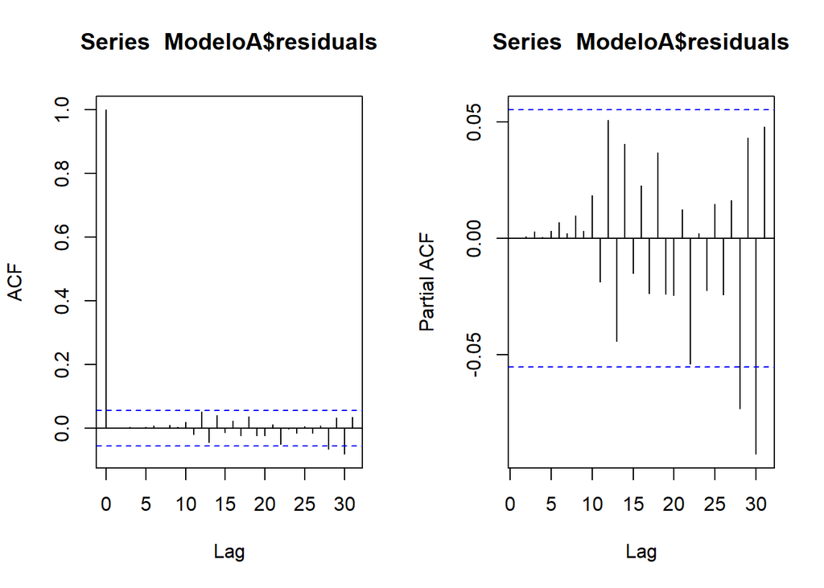

```r
par(mfrow = c(1,2))
acf(ModeloA$residuals)
pacf(ModeloA$residuals)
```

```r
BIC(ModeloA)
```

```
## [1] 7263.262
```

Basado en el autocorrelograma, no considero que el modelo sea el mejor ya que el objetivo es que los residuales no estén correlacionados y poder cumplir el supuesto de que son independientes y que están identicamente distribuidos, podemos ver que en el autocorrelograma algunos residuales pasan el intervalo de canfianza, y por ende hay autocorrelación lo cual nos lleva a violar el supuesto dicho anteriormente, por lo tanto se puede concluir que no es el mejor modelo.

4. (*15 puntos*) Estime el modelo que implican los resultados del punto 3. Además, estime el modelo ARMA(p+1,q+1) correspondiente, e.g. si el modelo escogido es un AR(2) [ARMA(2,0)] deben estimar un ARMA(3,1). ¿Son los coeficientes agregados al segundo modelo significativos? ¿Que implicaciones tiene esto sobre el modelo?

```r
library(forecast)
library(lmtest)
ModeloA<-Arima(ret,
      order = c(10,0,12))
coeftest(ModeloA)
```

```
##
## z test of coefficients:
##
##            Estimate Std. Error z value  Pr(>|z|)
## ar1       -0.526314   0.124140 -4.2397 2.238e-05 ***
## ar2       -0.312947   0.155376 -2.0141 0.0439961 *
## ar3       -0.386202   0.203519 -1.8976 0.0577460 .
## ar4       -0.054699   0.138874 -0.3939 0.6936722
## ar5       -0.128342   0.126134 -1.0175 0.3089154
## ar6       -0.275443   0.138096 -1.9946 0.0460884 *
## ar7       -0.340919   0.129290 -2.6369 0.0083679 **
## ar8       -0.308305   0.142056 -2.1703 0.0299843 *
## ar9       -0.238216   0.197524 -1.2060 0.2278137
## ar10      -0.221469   0.140858 -1.5723 0.1158829
## ma1        0.662324   0.121324  5.4591 4.785e-08 ***
## ma2        0.505547   0.160620  3.1475 0.0016469 **
## ma3        0.523079   0.213993  2.4444 0.0145105 *
## ma4        0.142336   0.164113  0.8673 0.3857728
## ma5        0.130695   0.125986  1.0374 0.2995581
## ma6        0.198028   0.143039  1.3844 0.1662266
## ma7        0.364579   0.131254  2.7777 0.0054751 **
## ma8        0.367923   0.143364  2.5663 0.0102776 *
## ma9        0.350392   0.194260  1.8037 0.0712740 .
## ma10       0.385154   0.162097  2.3761 0.0174982 *
## ma11       0.177984   0.047994  3.7084 0.0002085 ***
## ma12       0.268782   0.032101  8.3730 < 2.2e-16 ***
## intercept  0.150325   0.151983  0.9891 0.3226185
## ---
## Signif. codes:  0 '***' 0.001 '**' 0.01 '*' 0.05 '.' 0.1 ' ' 1
```

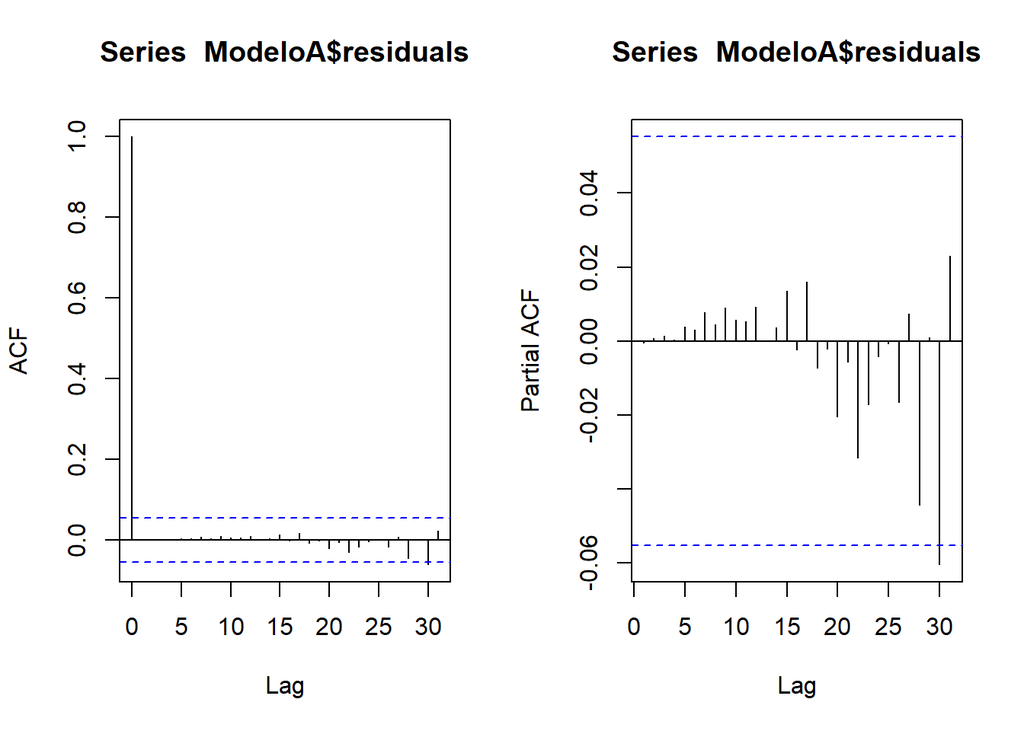

```r
par(mfrow = c(1,2))
acf(ModeloA$residuals)
pacf(ModeloA$residuals)
```

```r
BIC(ModeloA)
```

```
## [1] 7255.983
```

5. (*8 puntos*) Entre los modelos estimados, ¿Cual considera usted que es el mejor modelo? ¿Por qué?

Entre los dos modelos estimados, considero que el mejor modelo es el ARIMA(10,0,12) ya que se puede observa que hay menor autocorrelación entre los residuales.Se puede ver que al aumentar los valores p y q en el modelo ARIMA,la correlación disminuye y tenderá más a comportarse como un ruido blanco.

También elijo el modelo ARIMA(10,0,12) porque su creiterio de información BIC es más bajo que el del modelo ARIMA(9,0,11). lo que nos dice el criterio de información BIC nos dice que entre menor sea BIC del modelo, será considerado el mejor.